# Prediction Assignment Writeup

Gianmarco Polotti

26/8/2020

Final report of the Peer Assessment project from Coursera’s course Practical Machine Learning. The goal of the project is to predict in which way 6 participants (asked to perform barbell lifts correctly and incorrectly) performe some exercises executed and monitored by some sensors. Maasurements are classified in 5 categories: * correct exercise (Class A) * Elbows to the front (Class B) * Lifting the dumbbell not enough (Class C) * Lowering the dumbbell not enough (Class D) * Throwing the hips in front (Class E) The model is applied to a given training data with many predictors and trails and it must exactly predict 20 test conditions.

## Data Import

Data for this project are available here:

https://d396qusza40orc.cloudfront.net/predmachlearn/pml-training.csv https://d396qusza40orc.cloudfront.net/predmachlearn/pml-testing.csv

And commented in:

Velloso, E.; Bulling, A.; Gellersen, H.; Ugulino, W.; Fuks, H. “Qualitative Activity Recognition of Weight Lifting Exercises. Proceedings of 4th International Conference in Cooperation with SIGCHI (Augmented Human ’13)”. Stuttgart, Germany: ACM SIGCHI, 2013.

The first step is loading the dataset after download.

```r
training <- read.csv("pml-training.csv", header=T, na.strings=c("NA","","#DIV/0!"))
testing  <- read.csv("pml-testing.csv", header=T, na.strings=c("NA","","#DIV/0!"))
```

## Data Cleaning

Data rare spurious. Some missing values are present and must be removed. Moreover, the first seven column are used to identify tests and exercise, so they have to be removed. These is done in the following code.

```r
# remove identifiers
training <- training[, -(1:7)]
testing  <- testing[, -(1:7)]
# remove variable with missing data
training<-training[,colSums(is.na(training)) == 0]
testing<-testing[,colSums(is.na(testing)) == 0]
dim(training)
```

```
## [1] 19622    53
```

```r
dim(testing)
```

```
## [1] 20 53
```

## Correlation Analysis

A correlation among variables is helpfull before building the model.

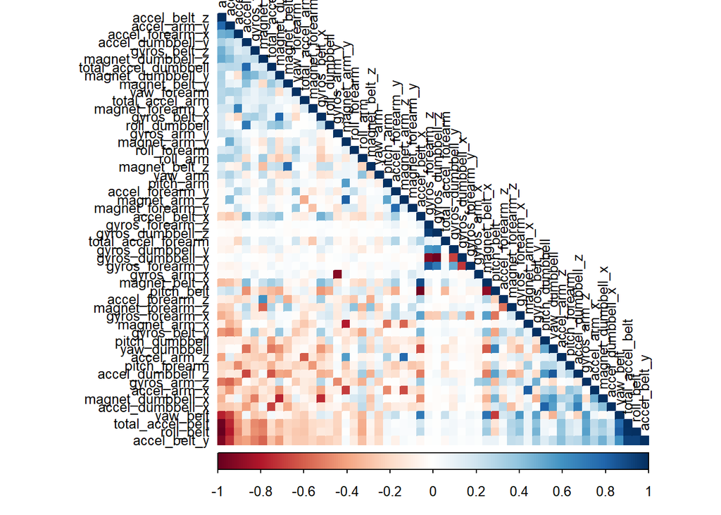

```r
corMatrix <- cor(training[, -ncol(training)])
corrplot(corMatrix, order = "FPC", method = "color", type = "lower", tl.cex = 0.8, tl.col = rgb(0, 0, 0))
```

The highly correlated variables are shown in dark colors in the graph above. They are not too many and so I can go on dealing with unchanged data.

## Validation and Train Set Split

A model selection need to be done since it is not evident which techniques is the better. So a Validation Set is build from the Training Set. As a Training set I use only 80% of the data and I suse as Validation Set the remaining 20%. Test Set remains unchanged and unused in this part.

```r
inTrain  <- createDataPartition(training$classe, p=0.8, list=FALSE)
TrainSet <- training[inTrain, ]
ValSet  <- training[-inTrain, ]
dim(TrainSet)
```

```
## [1] 15699    53
```

```r
dim(ValSet)
```

```
## [1] 3923   53
```

## Models Fitting

I use three different techniques that I compare by the Confusion Matrix build on the Validation Set.

## Random Forest

```r
controlRF <- trainControl(method="cv", number=3, verboseIter=FALSE)
modFitRF <- train(classe ~ ., data=TrainSet, method="rf",trControl=controlRF)
modFitRF$finalModel
```

```
##
## Call:
##  randomForest(x = x, y = y, mtry = param$mtry)
##                Type of random forest: classification
##                      Number of trees: 500
## No. of variables tried at each split: 27
##
##         OOB estimate of  error rate: 0.54%
## Confusion matrix:
##      A    B    C    D    E class.error
## A 4461    1    1    0    1 0.000672043
## B   17 3016    5    0    0 0.007241606
## C    0    9 2718   11    0 0.007304602
## D    0    1   24 2546    2 0.010493587
## E    0    0    3   10 2873 0.004504505
```

```r
predictRF <- predict(modFitRF, newdata=ValSet)
confMatRF <- confusionMatrix(predictRF, factor(ValSet$classe))
confMatRF
```

```
## Confusion Matrix and Statistics
##
##           Reference
## Prediction    A    B    C    D    E
##          A 1113    3    0    0    0
##          B    3  754    3    0    0
##          C    0    2  679    8    3
##          D    0    0    2  635    1
##          E    0    0    0    0  717
##
## Overall Statistics
##
##                Accuracy : 0.9936
##                  95% CI : (0.9906, 0.9959)
##     No Information Rate : 0.2845
##     P-Value [Acc > NIR] : < 2.2e-16
##
##                   Kappa : 0.9919
##
##  Mcnemar's Test P-Value : NA
##
## Statistics by Class:
##
##                      Class: A Class: B Class: C Class: D Class: E
## Sensitivity            0.9973   0.9934   0.9927   0.9876   0.9945
## Specificity            0.9989   0.9981   0.9960   0.9991   1.0000
## Pos Pred Value         0.9973   0.9921   0.9812   0.9953   1.0000
## Neg Pred Value         0.9989   0.9984   0.9985   0.9976   0.9988
## Prevalence             0.2845   0.1935   0.1744   0.1639   0.1838
## Detection Rate         0.2837   0.1922   0.1731   0.1619   0.1828
## Detection Prevalence   0.2845   0.1937   0.1764   0.1626   0.1828
## Balanced Accuracy      0.9981   0.9958   0.9943   0.9933   0.9972
```

## Decision Tree

[figure not shown]

```r
modFitDT <- rpart(classe ~ ., data=TrainSet, method="class")
fancyRpartPlot(modFitDT)
```

```r
predictDT <- predict(modFitDT, newdata=ValSet, type="class")
confMatDT <- confusionMatrix(predictDT, factor(ValSet$classe))
confMatDT
```

```
## Confusion Matrix and Statistics
##
##           Reference
## Prediction    A    B    C    D    E
##          A 1032  169   24   72   40
##          B   18  426   54   18   49
##          C   17   70  550   95   78
##          D   28   59   36  408   31
##          E   21   35   20   50  523
##
## Overall Statistics
##
##                Accuracy : 0.7492
##                  95% CI : (0.7353, 0.7627)
##     No Information Rate : 0.2845
##     P-Value [Acc > NIR] : < 2.2e-16
##
##                   Kappa : 0.6806
##
##  Mcnemar's Test P-Value : < 2.2e-16
##
## Statistics by Class:
##
##                      Class: A Class: B Class: C Class: D Class: E
## Sensitivity            0.9247   0.5613   0.8041   0.6345   0.7254
## Specificity            0.8913   0.9561   0.9197   0.9530   0.9606
## Pos Pred Value         0.7719   0.7540   0.6790   0.7260   0.8059
## Neg Pred Value         0.9675   0.9008   0.9570   0.9301   0.9395
## Prevalence             0.2845   0.1935   0.1744   0.1639   0.1838
## Detection Rate         0.2631   0.1086   0.1402   0.1040   0.1333
## Detection Prevalence   0.3408   0.1440   0.2065   0.1433   0.1654
## Balanced Accuracy      0.9080   0.7587   0.8619   0.7938   0.8430
```

## Generalized Boosted Model

```r
controlGBM <- trainControl(method = "repeatedcv", number = 5, repeats = 1)
modFitGBM  <- train(classe ~ ., data=TrainSet, method = "gbm", trControl = controlGBM, verbose = FALSE)
modFitGBM$finalModel
```

```
## A gradient boosted model with multinomial loss function.
## 150 iterations were performed.
## There were 52 predictors of which 52 had non-zero influence.
```

```r
predictGBM <- predict(modFitGBM, newdata=ValSet)
confMatGBM <- confusionMatrix(predictGBM,factor(ValSet$classe))
confMatGBM
```

```
## Confusion Matrix and Statistics
##
##           Reference
## Prediction    A    B    C    D    E
##          A 1100   22    0    0    4
##          B   11  714   18    3    9
##          C    3   20  660   20    6
##          D    1    2    6  616    9
##          E    1    1    0    4  693
##
## Overall Statistics
##
##                Accuracy : 0.9643
##                  95% CI : (0.958, 0.9699)
##     No Information Rate : 0.2845
##     P-Value [Acc > NIR] : < 2.2e-16
##
##                   Kappa : 0.9548
##
##  Mcnemar's Test P-Value : 0.0004608
##
## Statistics by Class:
##
##                      Class: A Class: B Class: C Class: D Class: E
## Sensitivity            0.9857   0.9407   0.9649   0.9580   0.9612
## Specificity            0.9907   0.9870   0.9849   0.9945   0.9981
## Pos Pred Value         0.9769   0.9457   0.9309   0.9716   0.9914
## Neg Pred Value         0.9943   0.9858   0.9925   0.9918   0.9913
## Prevalence             0.2845   0.1935   0.1744   0.1639   0.1838
## Detection Rate         0.2804   0.1820   0.1682   0.1570   0.1767
## Detection Prevalence   0.2870   0.1925   0.1807   0.1616   0.1782
## Balanced Accuracy      0.9882   0.9639   0.9749   0.9763   0.9796
```

## Results Comparison and Final Test

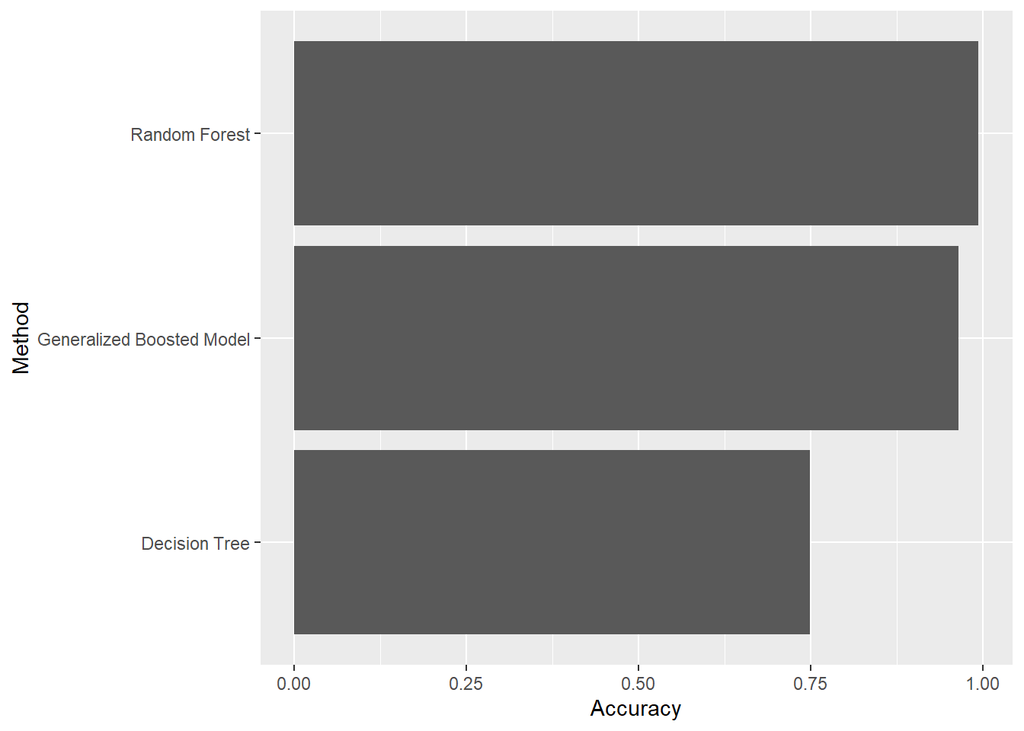

```r
df<-data.frame(Method=c("Random Forest","Decision Tree","Generalized Boosted Model"),
Accuracy=c(confMatRF$overall['Accuracy'],confMatDT$overall['Accuracy'],confMatGBM$overall['Accuracy']))

p<-ggplot(data=df, aes(x=Method, y=Accuracy)) +
  geom_bar(stat="identity")+coord_flip()
p
```

Since it comes out from the comparison that the most efficient technique is the **Random Forest**, I use it to perform the final test on the 20 unknow execices.

```r
predictTEST <- predict(modFitRF, newdata=testing)
predictTEST
```

```
##  [1] B A B A A E D B A A B C B A E E A B B B
## Levels: A B C D E
```